# Take Home Exam #1

Yihan Wang (April)

February 24, 2024

## Rules

```r
2 + 2
# 4
```

1. You may only use `tidyverse` and `nycflights13` (and its dependencies) for this assignment. Your solutions may not use any other R packages.

## Academic Integrity Statement

*I, Yihan (April) Wang, hereby state that I have not communicated with or gained information in any way from my classmates or anyone other than the Professor or TA during this exam, and that all work is my own.*

**A note on sharing / reusing code:** I am well aware that a huge volume of code is available on the web to solve any number of problems. For this exam you are allowed to make use of any online resources (e.g. StackOverflow) but you must explicitly cite where you obtained any code you directly use (or use as inspiration). You are also not allowed to ask a question on an external forum, you can only use answers to questions that have already been answered. Any recycled code that is discovered and is not explicitly cited will be treated as plagiarism. All communication with classmates is explicitly forbidden.

## Getting help

You are not allowed to post any questions on the public community repo or the public questions channel on Slack. Any questions about the exam must be asked in person in office hours or on Slack via direct message to the Professor or the TAs. For quickest response we recommend that you start a direct message with the Professor and all the TAs so that whoever gets to it first can respond to you.

## Grading and feedback

The total points for the questions add up to 90 points. The remaining 10 points are allocated to code style, commit frequency and messages, overall organization, spelling, grammar, etc. There is also an extra credit question that is worth 5 points. You will receive feedback as an issue posted to your repository, and your grade will also be recorded on Sakai.

## Logistics

Answer the questions in the document called `exam-01.Rmd`. Add your code and narrative in the spaces below each question. Add code chunks as needed. Use as many lines as you need, but keep your narrative concise.

Before completing, make sure to supress the code and look over your answers one more time. If the narrative seems sparse or choppy, edit as needed. Then, revert back to revealing your code.

Don’t forget that you will need to configure your user name and email for Git to be able to push to your repository.

## Packages

In addition to `tidyverse`, you will need the `nycflights13` package for the data. You will first need to install these packages and then load them.

## The data

The `nycflights13` package contains information about all flights that departed from NYC (e.g. EWR, JFK and LGA) in 2013. The main data is in the `flights` data frame, but there are additional data sets which may help understand what causes delays, specifically:

- `weather`: hourly meteorological data for each airport
- `planes`: construction information about each plane
- `airports`: airport names and locations
- `airlines`: translation between two letter carrier codes and names

## Questions

```r
library(tidyverse)
library(nycflights13)
```

1. **Question 1 (10 points)** - What are the ten most common destinations for flights from NYC airports in 2013? Make a table that lists these in descending order of frequency and shows the number of fligts heading to each airport.

```r
top_destinations <- flights %>%
  group_by(dest) %>%
  summarise(NumberOfFlights = n()) %>%
  arrange(desc(NumberOfFlights)) %>%
  slice_head(n = 10)

top_destinations
```

```
## # A tibble: 10 × 2
##    dest  NumberOfFlights
##    <chr>           <int>
##  1 ORD             17283
##  2 ATL             17215
##  3 LAX             16174
##  4 BOS             15508
##  5 MCO             14082
##  6 CLT             14064
##  7 SFO             13331
##  8 FLL             12055
##  9 MIA             11728
## 10 DCA              9705
```

2. **Question 2 (10 points)** - Which airlines have the most flights departing from NYC airports in 2013? Make a table that lists these in descending order of frequency and shows the number of flights for each airline. In your narrative mention the names of the airlines as well. *Hint:* You can use the `airlines` dataset to look up the airline name based on `carrier` code.

```r
flight_counts <- flights %>%
   group_by(carrier) %>%
   summarise(number_of_flights = n()) %>%
   arrange(desc(number_of_flights))
flight_counts_with_names <- flight_counts %>%
   left_join(airlines, by = "carrier") %>%
   select(name, number_of_flights)
flight_counts_with_names
```

```
## # A tibble: 16 × 2
##    name                        number_of_flights
##    <chr>                                   <int>
##  1 United Air Lines Inc.                   58665
##  2 JetBlue Airways                         54635
##  3 ExpressJet Airlines Inc.                54173
##  4 Delta Air Lines Inc.                    48110
##  5 American Airlines Inc.                  32729
##  6 Envoy Air                               26397
##  7 US Airways Inc.                         20536
##  8 Endeavor Air Inc.                       18460
##  9 Southwest Airlines Co.                  12275
## 10 Virgin America                           5162
## 11 AirTran Airways Corporation              3260
## 12 Alaska Airlines Inc.                      714
## 13 Frontier Airlines Inc.                    685
## 14 Mesa Airlines Inc.                        601
## 15 Hawaiian Airlines Inc.                    342
## 16 SkyWest Airlines Inc.                      32
```

3. **Question 3 (10 points)** - Consider only flights that have non-missing arrival delay information. Your answer should include the name of the carrier in addition to the carrier code and the values asked.

   a. Which carrier had the highest mean arrival delay?

```r
flights %>%
  filter(!is.na(arr_delay)) %>%
  group_by(carrier) %>%
  summarise(mean_arr_delay = mean(arr_delay)) %>%
  arrange(desc(mean_arr_delay)) %>%
  inner_join(airlines, by = "carrier") %>%
  slice(c(1))
```

```
## # A tibble: 1 × 3
##   carrier mean_arr_delay name
##   <chr>            <dbl> <chr>
## 1 F9                21.9 Frontier Airlines Inc.
```

```
b\.
Which carrier had the lowest mean arrival delay?
```

```r
flights %>%
  filter(!is.na(arr_delay)) %>%
  group_by(carrier) %>%
  summarise(mean_arr_delay = mean(arr_delay)) %>%
  arrange(mean_arr_delay) %>%
  inner_join(airlines, by = "carrier") %>%
  slice(c(1))
```

```
## # A tibble: 1 × 3
##   carrier mean_arr_delay name
##   <chr>            <dbl> <chr>
## 1 AS               -9.93 Alaska Airlines Inc.
```

4. **Question 4 (10 points)** - What was the mean temperature at the origin airport on the day with the highest departure delay? Your answer should include the name of origin airport, the date with the highest departure delay, and the mean temperature on that day.

```r
flights %>%
  arrange(desc(dep_delay)) %>%
  slice(1) %>%
  select(dep_delay, month, day, origin)
```

```
## # A tibble: 1 × 4
##   dep_delay month   day origin
##       <dbl> <int> <int> <chr>
## 1      1301     1     9 JFK
```

```r
weather %>%
  filter(month == 1, day == 9, origin == "JFK") %>%
  summarise(mean_temp = mean(temp))
```

```
## # A tibble: 1 × 1
##   mean_temp
##       <dbl>
## 1      42.7
```

5. **Question 5 (15 points)** - Consider breaking the day into four time intervals: 12:01am-6am, 6:01am-12pm, 12:01pm-6pm, 6:01pm-12am.

   a. Calculate the proportion of flights that are delayed at departure at each of these time intervals.

```r
flights <- flights %>%
  mutate(time_of_day = case_when(
    sched_dep_time >= 001  & sched_dep_time <= 600  ~ "12:01am-6am",
    sched_dep_time >= 601  & sched_dep_time <= 1200 ~ "6:01am-12pm",
    sched_dep_time >= 1201 & sched_dep_time <= 1800 ~ "12:01pm-6pm",
    sched_dep_time >= 1801                          ~ "6:01pm-12am"))

flights %>%
  filter(!is.na(dep_delay)) %>%
  mutate(dep_delayed = ifelse(dep_delay > 0, "delayed", "ontime")) %>%
  count(time_of_day, dep_delayed) %>%
  group_by(time_of_day) %>%
  mutate(prop_delayed = n / sum(n)) %>%
  filter(dep_delayed == "delayed") %>%
  arrange(prop_delayed)
```

```
## # A tibble: 4 × 4
## # Groups:   time_of_day [4]
##   time_of_day dep_delayed     n prop_delayed
##   <chr>       <chr>       <int>        <dbl>
## 1 12:01am-6am delayed      1819        0.207
## 2 6:01am-12pm delayed     32466        0.260
## 3 12:01pm-6pm delayed     58325        0.463
## 4 6:01pm-12am delayed     35822        0.520
```

```
b\.
Comment on how the likelihood of being delayed change throughout the day?
```

6. **Question 6 (15 points)** - Find the flight with the longest air time.

   a. How long is this flight?

```r
longest_flight <-flights %>%
  filter(!is.na(air_time)) %>%
  arrange(desc(air_time)) %>%
  slice(1)
longest_flight$air_time
```

```
## [1] 695
```

```
b\.
What city did it fly to?
```

```r
airports %>%
  filter(faa == longest_flight$dest) %>%
  select(name)
```

```
## # A tibble: 1 × 1
##   name
##   <chr>
## 1 Honolulu Intl
```

```
c\.
How many seats does the plane that flew this flight have?
```

```r
longest_flight %>%
  select(tailnum) %>%
  inner_join(planes, by = "tailnum") %>%
  select(tailnum, seats)
```

```
## # A tibble: 1 × 2
##   tailnum seats
##   <chr>   <int>
## 1 N77066    292
```

7. **Question 7 (15 pts)** - The `airports` data frame contains information on a large number of primarily American airports. These data include location information for these airports in the form of latitude and longitude coordinates. In this question we limit our focus to the [Contiguous United States](https://en.wikipedia.org/wiki/Contiguous_United_States). Visualize and describe the distribution of the longitudes of airports in the Contiguous United States. What does this tell you about the geographical distribution of these airports? *Hint:* You will first need to limit your analysis to the Contiguous United States. [This Wikipedia article](https://en.wikipedia.org/wiki/List_of_extreme_points_of_the_United_States) can help, but you’re welcomed to use other resources as well. Make sure to cite whatever resource you use.

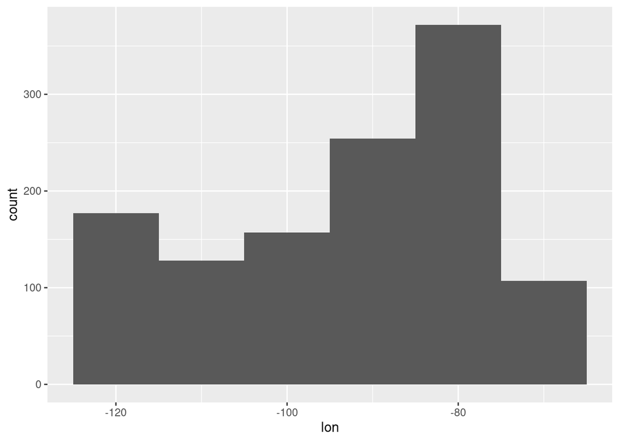

```r
airports %>%
  filter(
    lat > 24.520833333333332 & lat < 49.38447222222222,
    lon > -124.77169444444445 & lon < -66.94702777777778
  ) %>%
  ggplot(aes(x = lon)) +
    geom_histogram(binwidth = 10)
```

8. **Question 8 (15 pts)** - Recreate the plot included below using the `flights` data. Once you have created the visualization, in no more than one paragraph, describe what you think the point of this visualization might be. *Hint:* The visualization uses the variable `arrival`, which is not included in the `flights` data frame. You will have to create `arrival` yourself, it is a categorical variable that is equal to `"ontime"` when `arr_delay <= 0` and `"delayed"` when `arr_delay > 0`.

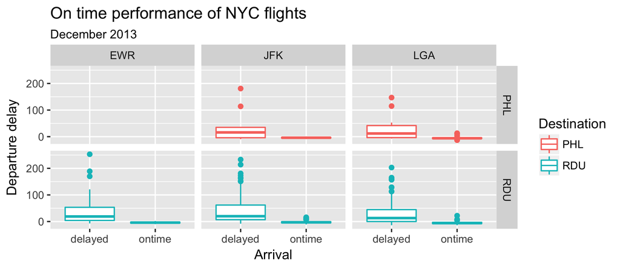

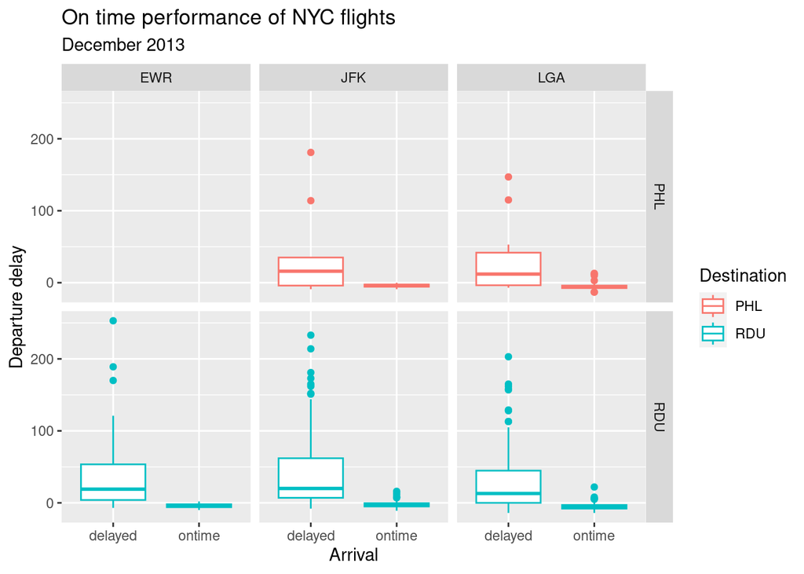

```r
flights %>%
  filter(month == 12, dest %in% c("PHL", "RDU")) %>%
  mutate(arrival = ifelse(arr_delay > 0, "delayed", "ontime")) %>%
  filter(!is.na(arrival)) %>%
  ggplot(aes(x = arrival, y = dep_delay, color = dest)) +
    geom_boxplot() +
    facet_grid(dest ~ origin) +
    labs(title = "On time performance of NYC flights",
         subtitle = "December 2013",
         x = "Arrival",
         y = "Departure delay",
         color = "Destination")
```

The plot shows the departure delay at December 13, comparing the flights to the destination of “PHL”, “RDU”.

**Extra Credit (5 pts)** - Create a visualization that effectively shows if there is a relationship between the average daily departure delay and the average daily temperature for all three New York city airports. Your answer must be given in a single pipe. (You should only spend time on this question once you have finished answering the others)

```r
flights_weather <- inner_join(flights, weather, by = c("year", "month", "day", "origin",
                                                       "hour")) %>%
  group_by(month, day, origin) %>%
  summarise(avg_dep_delay = mean(dep_delay, na.rm = TRUE),
            avg_temp = mean(temp, na.rm = TRUE))
```

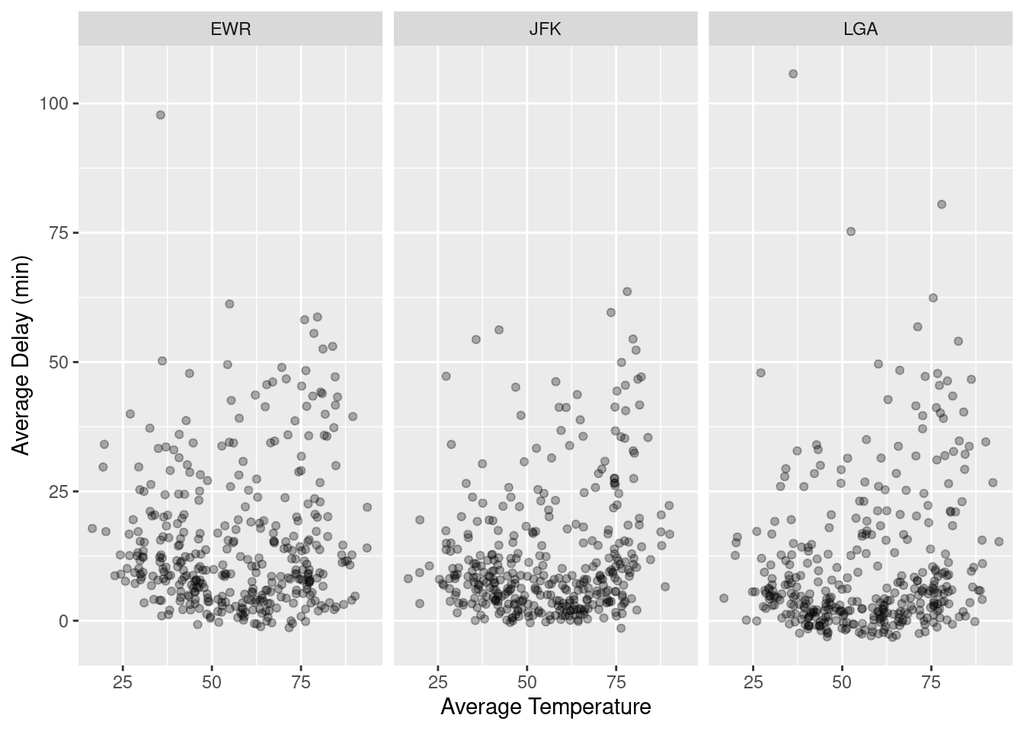

```r
ggplot(flights_weather, aes(x = avg_temp, y = avg_dep_delay)) +
  geom_point(alpha = 0.3) +
  facet_wrap(~ origin) +
  labs(x = "Average Temperature", y = "Average Delay (min)")
```